```
##  Hlavac, Marek (2018). stargazer: Well-Formatted Regression and Summary Statistics Tables.
```

```
##  R package version 5.2.2. https://CRAN.R-project.org/package=stargazer
```

```r
#read in the data
data <- read.csv(file = 'H:/ROL/MIDS/W203 Stats/lab_3/crime_v2.csv')
```

**2. A Model Building Process**

**Exploratory Data Analaysis**

We started by conducting exploratory data analysis. First, we read the original paper to get a better understanding of each variable. We defined the variables in the table below and grouped them into five groups in order to get a better handle on them.

```r
crime_count <- c(1:25)
data_variables <- c("county","year","crmrte","prbarr","prbconv","prbpris","avgsen","polpc","density","taxpc","west","central","urban","pctmin80","wcon","wtuc","wtrd","wfir","wser","wmfg","wfed","wsta","wloc","mix","pctymle")
data_description <- c("county identifier","1987","crimes committed per person","'probability' of arrest","'probability' of conviction","'probability' of prison sentence","avg. sentence, days","police per capita","people per sq. mile","tax revenue per capita","=1 if in western N.C.","=1 if in central N.C.","=1 if in SMSA","perc. minority, 1980","weekly wage, construction","wkly wge, trns, util, commun","wkly wge, whlesle, retail trade","wkly wge, fin, ins, real est","wkly wge, service industry","wkly wge, manufacturing","wkly wge, fed employees","wkly wge, state employees","wkly wge, local gov emps","offense mix: face-to-face/other","percent young male")
data_group <- c("Control","","","Deterrent","Deterrent","Deterrent","Deterrent","Deterrent","Demographic","Demographic","Region","Region","Urban","Demographic","Wages","Wages","Wages","Wages","Wages","Wages","Wages","Wages","Wages","Demographic","Demographic")
data_notes <- c("","","ratio of FBI index crimes to county population","ratio of arrests to offenses","ratio of convictions to arrests","proportion of total convictions resulting in prison sentences","average sentence in days","","country population divided by county land area","","dummy","dummy","dummy","proportion of country population that is minority or nonwhite","average weekly wage in that sector","average weekly wage in that sector","average weekly wage in that sector","average weekly wage in that sector","average weekly wage in that sector","average weekly wage in that sector","average weekly wage in that sector","average weekly wage in that sector","average weekly wage in that sector","ratio of face-to-face crimes (robbery, assault, rape) to non-face-to-face crimes","proportion of country population that is male between 15 and 24"
)
data_headers <- c("Variable", "Description", "Group", "Note")
data_table <- data.frame(data_variables, data_description, data_group, data_notes)
kable(data_table, col.names = data_headers, caption = "Descriptions and Groups of Variables")
```

Descriptions and Groups of Variables

| Variable | Description | Group | Note |
| --- | --- | --- | --- |
| county | county identifier | Control |  |
| year | 1987 |  |  |
| crmrte | crimes committed per person |  | ratio of FBI index crimes to county population |
| prbarr | ‘probability’ of arrest | Deterrent | ratio of arrests to offenses |
| prbconv | ‘probability’ of conviction | Deterrent | ratio of convictions to arrests |
| prbpris | ‘probability’ of prison sentence | Deterrent | proportion of total convictions resulting in prison sentences |
| avgsen | avg. sentence, days | Deterrent | average sentence in days |
| polpc | police per capita | Deterrent |  |
| density | people per sq. mile | Demographic | country population divided by county land area |
| taxpc | tax revenue per capita | Demographic |  |
| west | =1 if in western N.C. | Region | dummy |
| central | =1 if in central N.C. | Region | dummy |
| urban | =1 if in SMSA | Urban | dummy |
| pctmin80 | perc. minority, 1980 | Demographic | proportion of country population that is minority or nonwhite |
| wcon | weekly wage, construction | Wages | average weekly wage in that sector |
| wtuc | wkly wge, trns, util, commun | Wages | average weekly wage in that sector |
| wtrd | wkly wge, whlesle, retail trade | Wages | average weekly wage in that sector |
| wfir | wkly wge, fin, ins, real est | Wages | average weekly wage in that sector |
| wser | wkly wge, service industry | Wages | average weekly wage in that sector |
| wmfg | wkly wge, manufacturing | Wages | average weekly wage in that sector |
| wfed | wkly wge, fed employees | Wages | average weekly wage in that sector |
| wsta | wkly wge, state employees | Wages | average weekly wage in that sector |
| wloc | wkly wge, local gov emps | Wages | average weekly wage in that sector |
| mix | offense mix: face-to-face/other | Demographic | ratio of face-to-face crimes (robbery, assault, rape) to non-face-to-face crimes |
| pctymle | percent young male | Demographic | proportion of country population that is male between 15 and 24 |

To get a better sense of the data set the summary function was run.

```r
summary(data)
```

```
##      county           year        crmrte             prbarr
##  Min.   :  1.0   Min.   :87   Min.   :0.005533   Min.   :0.09277
##  1st Qu.: 52.0   1st Qu.:87   1st Qu.:0.020927   1st Qu.:0.20568
##  Median :105.0   Median :87   Median :0.029986   Median :0.27095
##  Mean   :101.6   Mean   :87   Mean   :0.033400   Mean   :0.29492
##  3rd Qu.:152.0   3rd Qu.:87   3rd Qu.:0.039642   3rd Qu.:0.34438
##  Max.   :197.0   Max.   :87   Max.   :0.098966   Max.   :1.09091
##  NA's   :6       NA's   :6    NA's   :6          NA's   :6
##         prbconv      prbpris           avgsen           polpc
##             : 5   Min.   :0.1500   Min.   : 5.380   Min.   :0.000746
##  0.588859022: 2   1st Qu.:0.3648   1st Qu.: 7.340   1st Qu.:0.001231
##  `          : 1   Median :0.4234   Median : 9.100   Median :0.001485
##  0.068376102: 1   Mean   :0.4108   Mean   : 9.647   Mean   :0.001702
##  0.140350997: 1   3rd Qu.:0.4568   3rd Qu.:11.420   3rd Qu.:0.001877
##  0.154451996: 1   Max.   :0.6000   Max.   :20.700   Max.   :0.009054
##  (Other)    :86   NA's   :6        NA's   :6        NA's   :6
##     density            taxpc             west           central
##  Min.   :0.00002   Min.   : 25.69   Min.   :0.0000   Min.   :0.0000
##  1st Qu.:0.54741   1st Qu.: 30.66   1st Qu.:0.0000   1st Qu.:0.0000
##  Median :0.96226   Median : 34.87   Median :0.0000   Median :0.0000
##  Mean   :1.42884   Mean   : 38.06   Mean   :0.2527   Mean   :0.3736
##  3rd Qu.:1.56824   3rd Qu.: 40.95   3rd Qu.:0.5000   3rd Qu.:1.0000
##  Max.   :8.82765   Max.   :119.76   Max.   :1.0000   Max.   :1.0000
##  NA's   :6         NA's   :6        NA's   :6        NA's   :6
##      urban            pctmin80           wcon            wtuc
##  Min.   :0.00000   Min.   : 1.284   Min.   :193.6   Min.   :187.6
##  1st Qu.:0.00000   1st Qu.: 9.845   1st Qu.:250.8   1st Qu.:374.6
##  Median :0.00000   Median :24.312   Median :281.4   Median :406.5
##  Mean   :0.08791   Mean   :25.495   Mean   :285.4   Mean   :411.7
##  3rd Qu.:0.00000   3rd Qu.:38.142   3rd Qu.:314.8   3rd Qu.:443.4
##  Max.   :1.00000   Max.   :64.348   Max.   :436.8   Max.   :613.2
##  NA's   :6         NA's   :6        NA's   :6       NA's   :6
##       wtrd            wfir            wser             wmfg
##  Min.   :154.2   Min.   :170.9   Min.   : 133.0   Min.   :157.4
##  1st Qu.:190.9   1st Qu.:286.5   1st Qu.: 229.7   1st Qu.:288.9
##  Median :203.0   Median :317.3   Median : 253.2   Median :320.2
##  Mean   :211.6   Mean   :322.1   Mean   : 275.6   Mean   :335.6
##  3rd Qu.:225.1   3rd Qu.:345.4   3rd Qu.: 280.5   3rd Qu.:359.6
##  Max.   :354.7   Max.   :509.5   Max.   :2177.1   Max.   :646.9
##  NA's   :6       NA's   :6       NA's   :6        NA's   :6
##       wfed            wsta            wloc            mix
##  Min.   :326.1   Min.   :258.3   Min.   :239.2   Min.   :0.01961
##  1st Qu.:400.2   1st Qu.:329.3   1st Qu.:297.3   1st Qu.:0.08074
##  Median :449.8   Median :357.7   Median :308.1   Median :0.10186
##  Mean   :442.9   Mean   :357.5   Mean   :312.7   Mean   :0.12884
##  3rd Qu.:478.0   3rd Qu.:382.6   3rd Qu.:329.2   3rd Qu.:0.15175
##  Max.   :598.0   Max.   :499.6   Max.   :388.1   Max.   :0.46512
##  NA's   :6       NA's   :6       NA's   :6       NA's   :6
##     pctymle
##  Min.   :0.06216
##  1st Qu.:0.07443
##  Median :0.07771
##  Mean   :0.08396
##  3rd Qu.:0.08350
##  Max.   :0.24871
##  NA's   :6
```

This function provides a high level view of each variable. Six rows have missing values for all variables. In addition, there is one duplicate row. Also the variable prbconv is loaded as a factor, so it needs to be converted to numeric. These issues are handled below to create the initial data set.

```r
#eliminate N/A's
data_crmrte <- data[!is.na(data$crmrte),]

#remove duplicates
data_crmrte <- data_crmrte %>% distinct()

#make prbconv numeric
data_crmrte$prbconv <- as.numeric(as.character(data_crmrte$prbconv))
```

With 25 original variables in the data set the natural place to start is with the dependent variable, crmrte. To get a better sense of this variable, the distribution is graphed below.

```r
quantile(data_crmrte$crmrte, c(0, .01, .05, .10, .25, .50,  .75, .90, .95, .99, 1.0))
```

```
##         0%         1%         5%        10%        25%        50%        75%
## 0.00553320 0.01006330 0.01235660 0.01418007 0.02060425 0.03000200 0.04024925
##        90%        95%        99%       100%
## 0.06054659 0.07191830 0.08954881 0.09896590
```

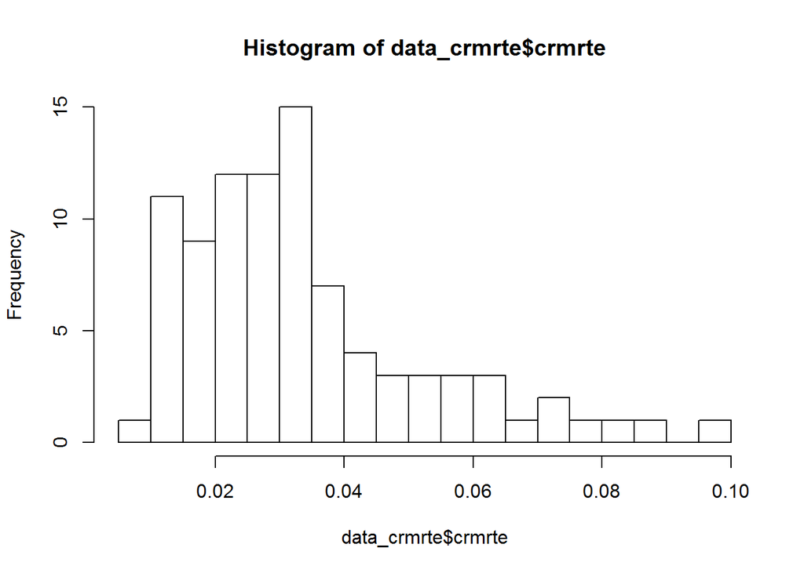

```r
hist(data_crmrte$crmrte,breaks=20)
```

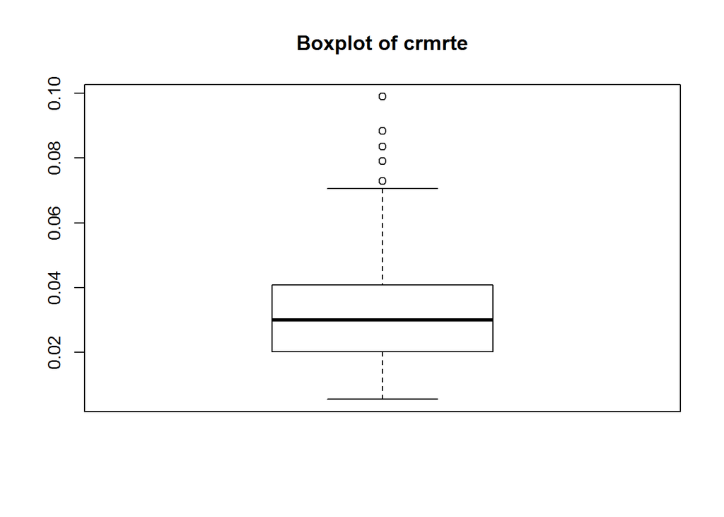

```r
boxplot(data_crmrte$crmrte, main="Boxplot of crmrte")
```

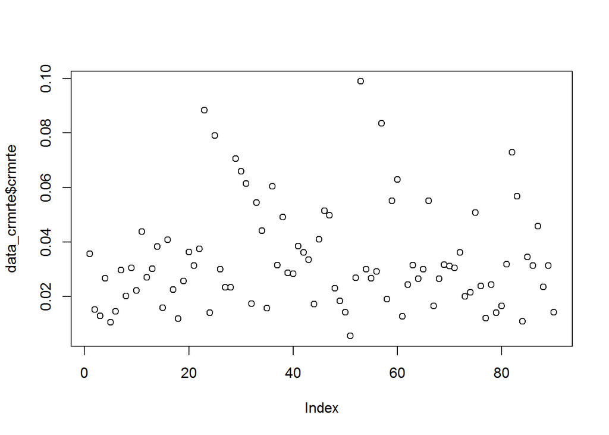

```r
plot(data_crmrte$crmrte)
```

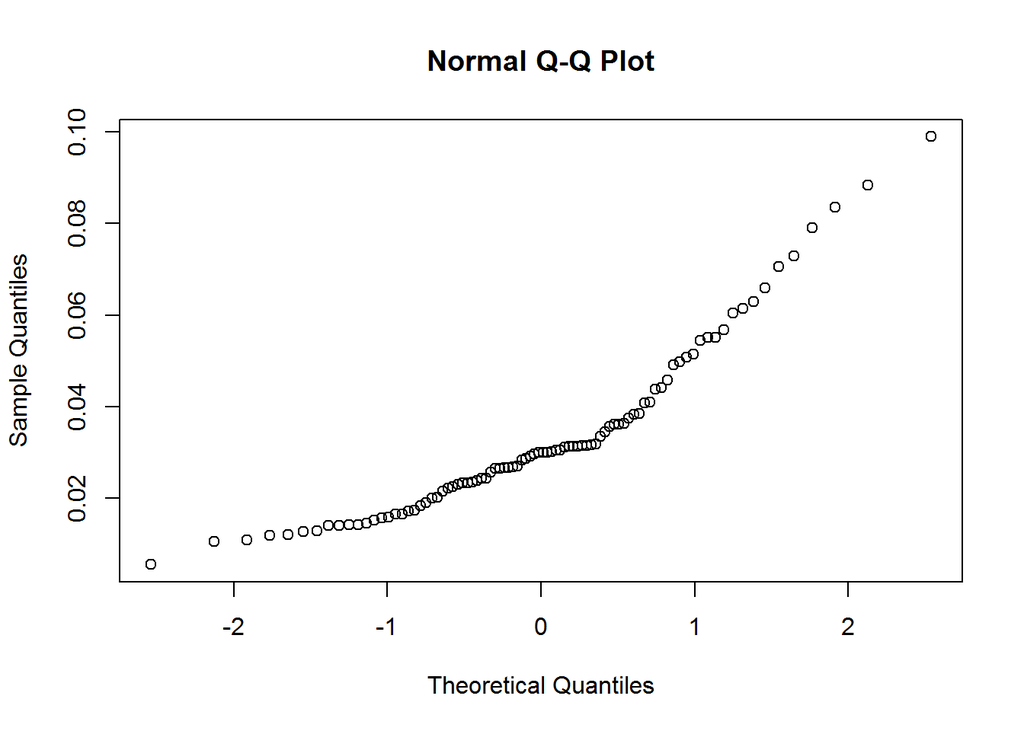

```r
qqnorm(data_crmrte$crmrte)
```

There are several outliers in the variable crmrte and the distribution is right skewed. We have ninety observations so perhaps we normality is not a top concern but this distribution is not perfectly normal. The largest outliers on the right side of the distribution are examined. Unfortunately, looking at these observations in a dataframe does not show any obvious patterns (e.g. they are all in the same region, they all have similar values of a variable like density, etc.)

```r
data_crmrte[data_crmrte$crmrte > 0.065,]
```

```
##    county year    crmrte   prbarr  prbconv  prbpris avgsen      polpc   density
## 23     51   87 0.0883849 0.155248 0.259833 0.407628  11.93 0.00190802 3.9345510
## 25     55   87 0.0790163 0.224628 0.207831 0.304348  13.57 0.00400962 0.5115089
## 29     63   87 0.0706599 0.133225 0.459216 0.363636  11.51 0.00237609 5.6744967
## 30     65   87 0.0658801 0.287330 0.154452 0.403922   9.84 0.00185739 1.1679842
## 53    119   87 0.0989659 0.149094 0.347800 0.486183   7.13 0.00223135 8.8276520
## 57    129   87 0.0834982 0.236601 0.393413 0.415158   9.57 0.00255849 6.2864866
## 82    181   87 0.0729479 0.182590 0.343023 0.548023   7.06 0.00172948 1.5702811
##        taxpc west central urban pctmin80     wcon     wtuc     wtrd     wfir
## 23  35.69936    0       0     1 37.77920 283.6695 412.4720 213.7524 324.8357
## 25 119.76145    0       0     0  6.49622 309.5238 445.2762 189.7436 284.5933
## 29  50.19918    0       1     1 38.22300 349.3267 548.9865 238.9154 435.1107
## 30  30.62824    0       0     0 51.69320 362.1527 540.1061 209.0579 316.2955
## 53  75.67243    0       1     1 28.54600 436.7666 548.3239 354.6761 509.4655
## 57  67.67963    0       0     1 23.04410 315.5760 392.0999 220.4530 363.2880
## 82  27.59179    0       1     0 44.62830 244.8362 365.4716 279.2273 325.0271
##        wser   wmfg   wfed   wsta   wloc        mix    pctymle
## 23 257.3344 441.72 433.94 367.34 333.71 0.10474319 0.14223780
## 25 221.3903 319.21 338.91 361.68 326.08 0.08437271 0.07613807
## 29 391.3081 646.85 563.77 415.51 362.58 0.07585382 0.09468981
## 30 216.4589 313.71 543.03 348.88 329.16 0.09364294 0.07622346
## 53 354.3007 494.30 568.40 329.22 379.77 0.16869897 0.07916495
## 57 292.7027 464.49 548.49 421.36 319.08 0.07871422 0.08109921
## 82 213.5822 290.69 453.53 317.23 286.45 0.10003893 0.07977433
```

For campaign purposes, we want to predict crime. We want our candidate to be able to say that he or she can reduce crime in order to win votes. What is the most effective way to convey that? Using crime rate as it appears in the data set is using the level of crime rate and would suggest the following statement as a campaign slogan - “I can reduce crime to this rate by doing x, y, and z”. Transforming crime rate into the log of crime rate allows for the statement “I can reduce crime by n% by doing x, y, and z.” We find the latter more powerful and meaningful to voters since voters have no idea about the level of crime rates. In addition, we will show that the transformation of crime rate imrpoves the normaility and distribution of the variable, which will often reduce skew in the errors as well.

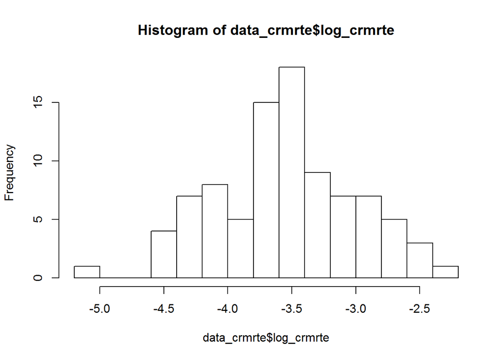

```r
data_crmrte$log_crmrte <- log(data_crmrte$crmrte)
hist(data_crmrte$log_crmrte,breaks=20)
```

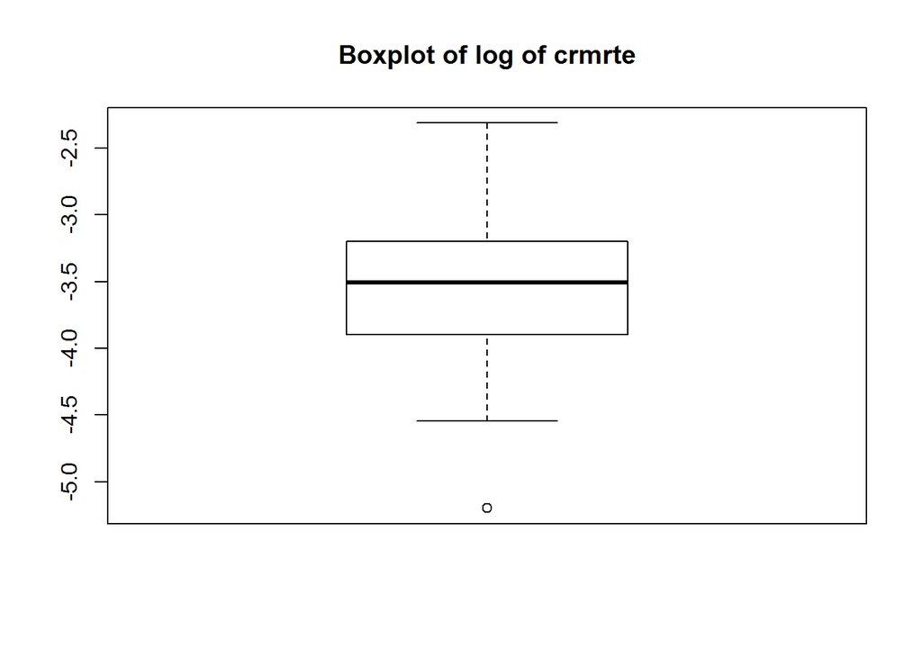

```r
boxplot(data_crmrte$log_crmrte, main="Boxplot of log of crmrte")
```

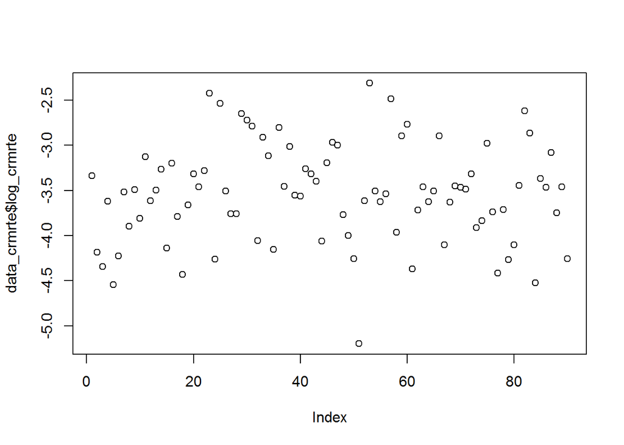

```r
plot(data_crmrte$log_crmrte)
```

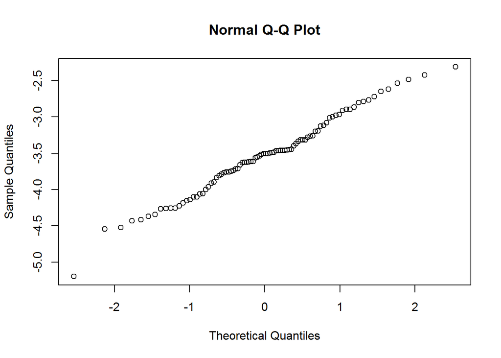

```r
qqnorm(data_crmrte$log_crmrte)
```

The histogram of the transformed crime rate is much more symmetrical and shows much less right skew. The box plot shows all of the outliers on the high end have been removed, though one outlier on the low end has been introduced. The scatter plot looks much more normal, and the Q-Q plot is much closer to normal with the data points hugging the 45 degree line much more closely. Given the stronger argument for the political campaign and the benefits to normality we have chosen to model the tranformation of crime rate as opposed to crime rate.

**Groupings**  
In order to digest the data in the data set we decided to group the variables into five groups: deterrent, wages, demographic, region, and urban. We performed exploratory data analysis on all of these variables.

The group is deterrent data. As cited in the original paper, these variables were hypothesized to reduce crime rate through disincentivizing crime. Essentially, as the probability of getting caught increases, criminals’ desire to commit crimes decreases.

**Deterrent Data**

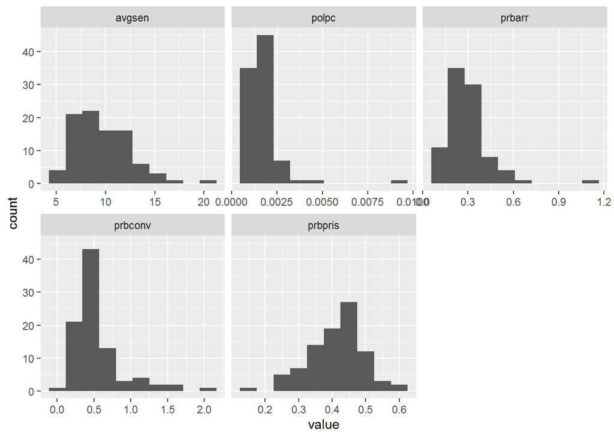

```r
deterrent_data <- data_crmrte[,c('prbarr','prbconv','prbpris','crmrte',
                          'avgsen','polpc')]

ggplot(gather(deterrent_data[,c('prbarr','prbconv','prbpris',
                                    'avgsen','polpc')]), aes(value)) +
geom_histogram(bins = 10) + facet_wrap(~key, scales = 'free_x')
```

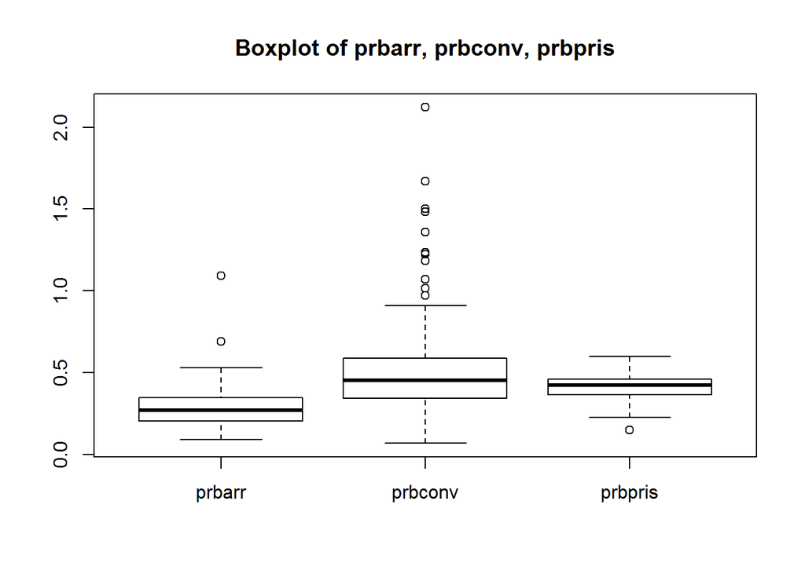

```r
my_vars1 <- c("prbarr","prbconv","prbpris")
deterrent_data2 <- deterrent_data[my_vars1]
my_vars2 <- c("polpc")
deterrent_data3 <- deterrent_data[my_vars2]

boxplot(deterrent_data2, main="Boxplot of prbarr, prbconv, prbpris")
```

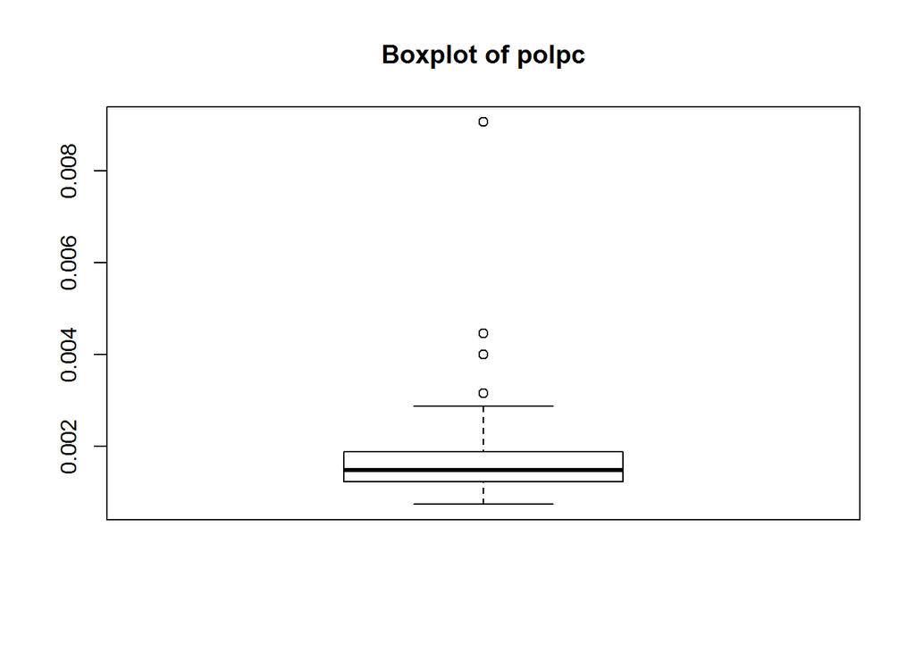

```r
boxplot(deterrent_data3, main="Boxplot of polpc")
```

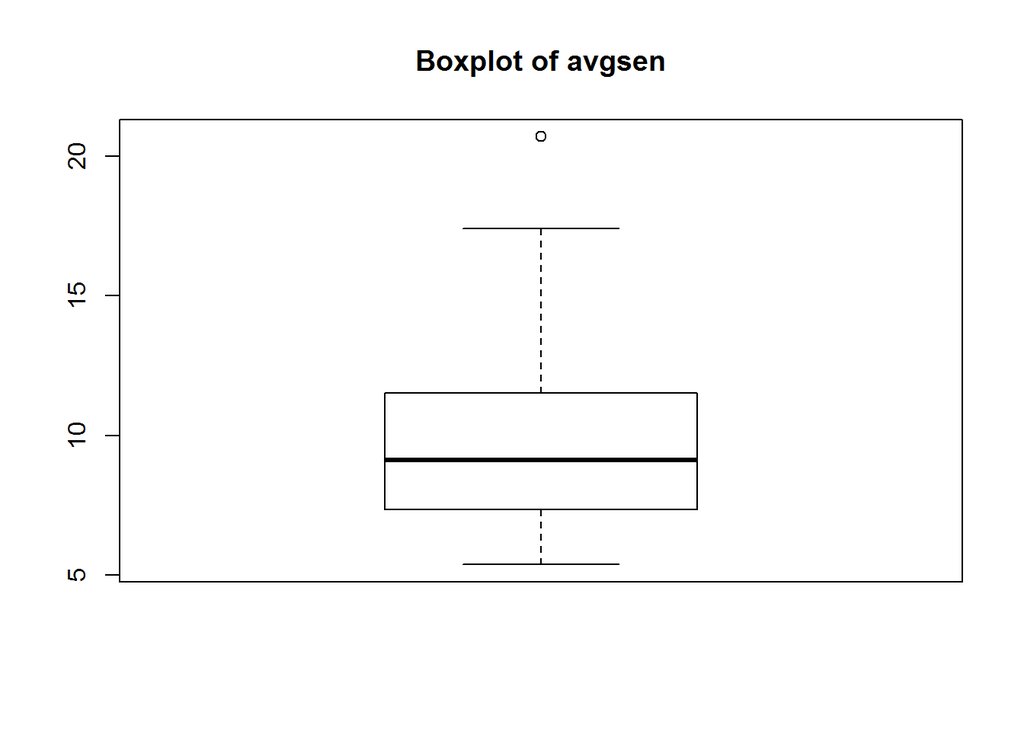

```r
boxplot(deterrent_data$avgsen, main="Boxplot of avgsen")
```

The first four histograms show right skew while prbpris shows left skew. The biggest outlier is observation 51. This observation has the lowest crime rate in the data set, obviously the highest polpc (police per capita), the highest avg sentence, the third highest prbconv, and the lowest pctmin80. This observation is likely to affect many of the regressions so it will need to be examined further. These variables are candidates to be transformed.

**Wages Data**

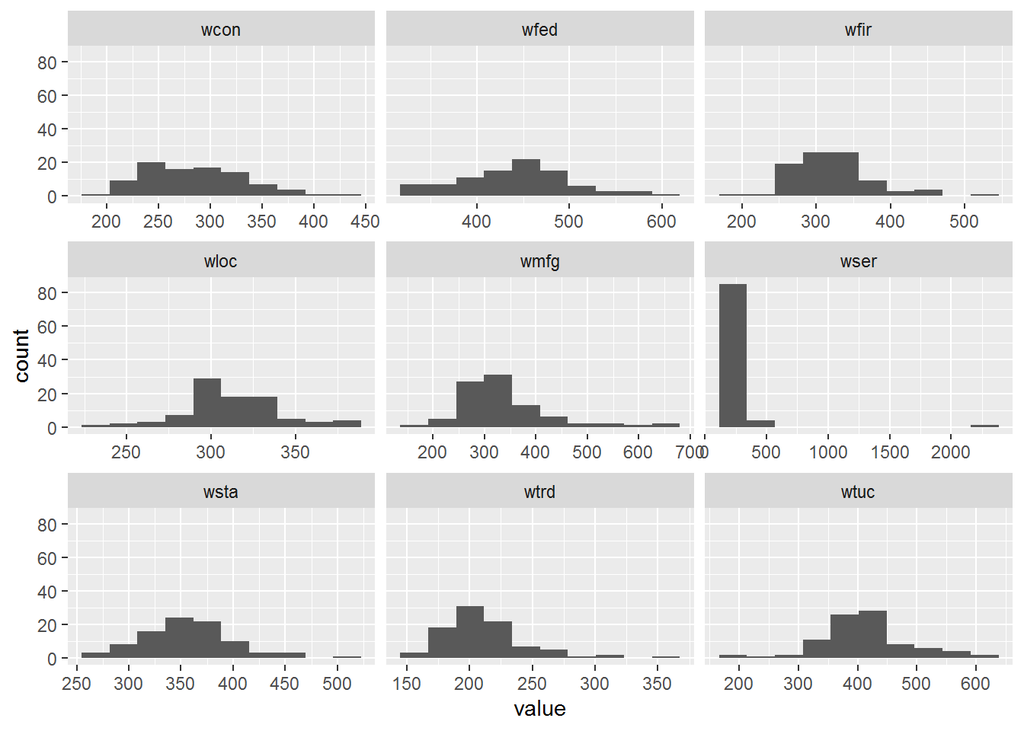

```r
#create a dataframe of just the wage variables
wages_data <- data_crmrte[,c('wcon','wtuc','wtrd','wfir', 'wser',
                      'wmfg','wfed', 'wsta', 'wloc')]

#plot histograms of just the wage variables
ggplot(gather(wages_data), aes(value)) +
  geom_histogram(bins = 10) +
  facet_wrap(~key, scales = 'free_x')
```

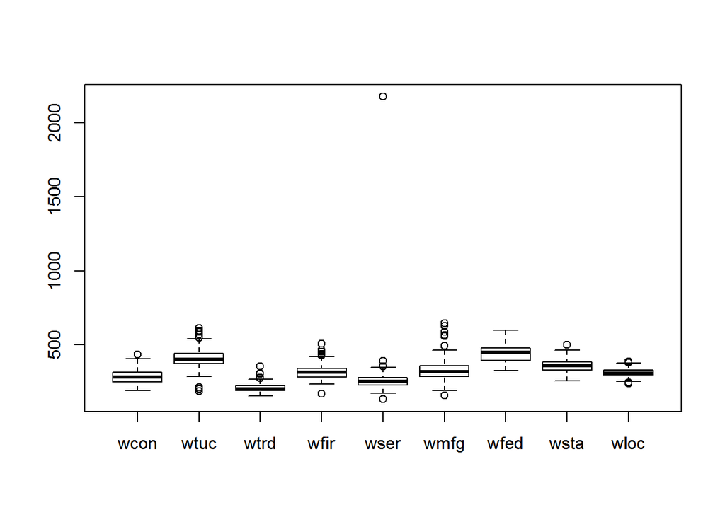

```r
#generate boxplots of just the wage variables
boxplot(wages_data)
```

There is an obvious outlier in wser. This seems like a typo. The next highest average weekly wage in any sector is 646 versus the value of 2177.If you take the average of all weekly wages it has the highest average but only the 24th highest taxpc (though tax revenue is driven largely by sales and property taxes, many areas have local income tax as well. It is very possible that it is an error but we will revisit this later. For now, we create an additional variable that is the median of all wage variables for each observation. If it conveys as much information, it has the benefit of increasing our degress of freedom and removing the effect of the outlier.

```r
data_crmrte$median_wage <- apply(data_crmrte[c("wcon", "wtuc", "wtrd",
                                               "wfir", "wser", "wmfg",
                                               "wfed", "wsta", "wloc")],
                                 1, FUN=median, na.rm=TRUE)
```

Region Data__

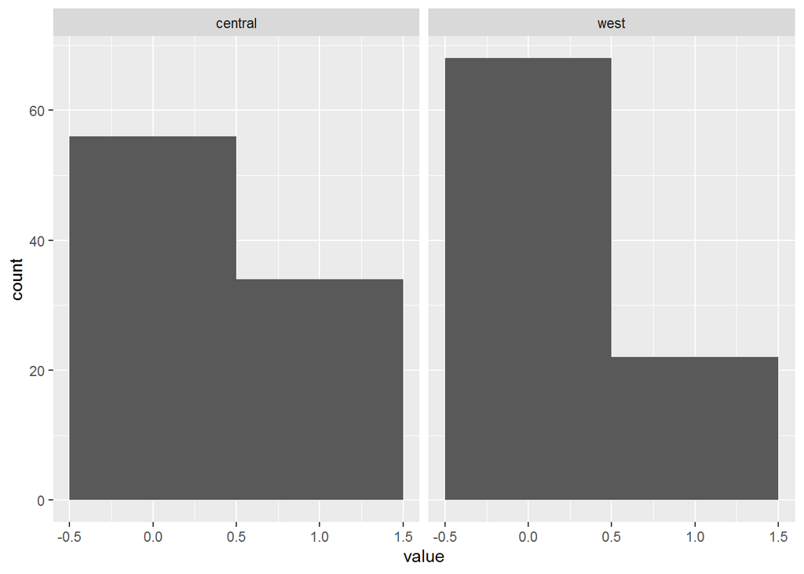

```r
#create a dataframe of just the wage variables
dummies_data <- data_crmrte[,c('west','central')]

#plot histograms of just the dummy variables
ggplot(gather(dummies_data), aes(value)) +
  geom_histogram(bins = 2) +
  facet_wrap(~key)
```

```r
#just a quick check that there is no overlap
region_check <- data_crmrte[which(data_crmrte$west == 1 && data_crmrte$central == 1)]
```

The regions are broken up into central, west, and east. East is left out of the data set and it’s effect as the final level of the indicator variable will move to the intercept.

**Urban Data**

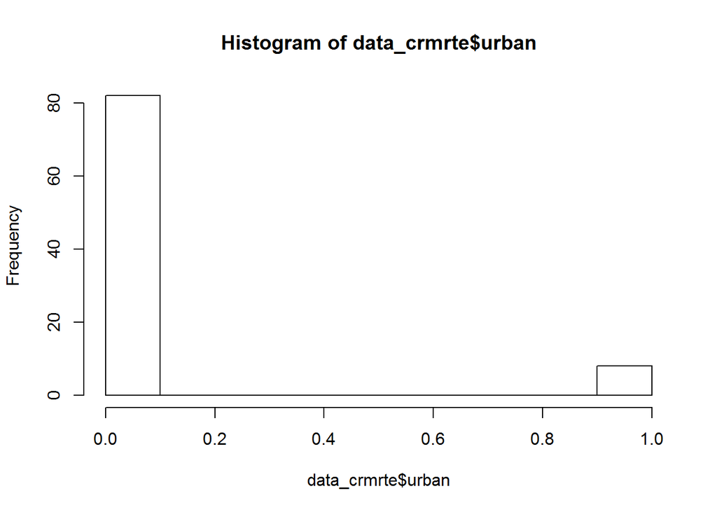

```r
#plot histograms of just the wage variables
hist(data_crmrte$urban)
```

Urban did not fit into a great grouping so we left this variable on its own. A histogram shows that the state has relatively few urban counties, something to keep in mind when analyzing other variables such as density.

**Demographic Data**

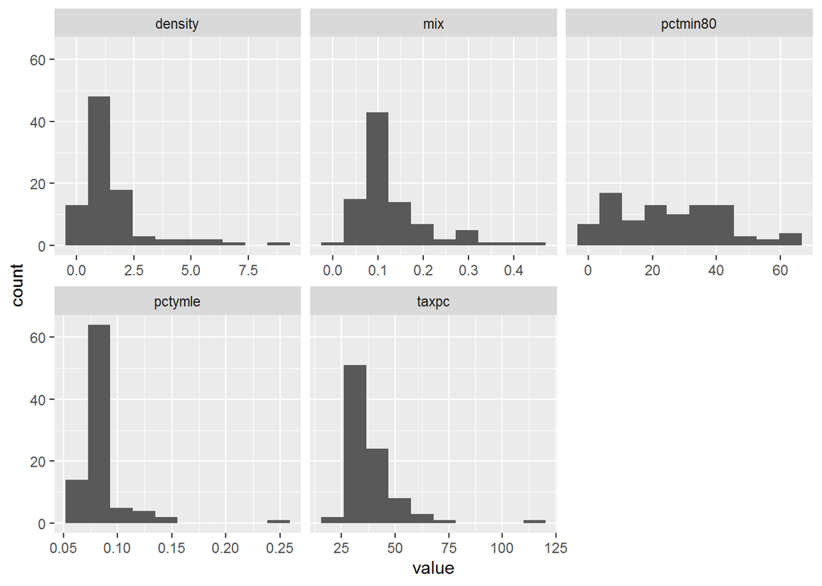

```r
#create a dataframe of just the demographic variables
demographic_data <- data_crmrte[,c('density', 'taxpc', 'pctmin80',
                                   'mix', 'pctymle')]

#plot histograms of just the demographic variables
ggplot(gather(demographic_data), aes(value)) +
  geom_histogram(bins = 10) +
  facet_wrap(~key, scales = 'free_x')
```

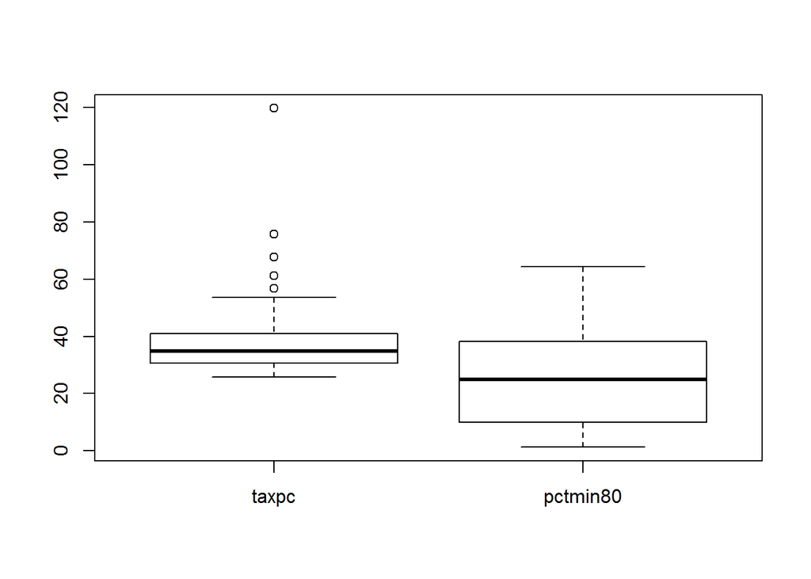

```r
#Lots of skewed distributions above, particularly in pctymle and taxpc
#generate boxplots of just the demographic variables
demographic_data2 <- demographic_data[c("taxpc", "pctmin80")]
boxplot(demographic_data2)
```

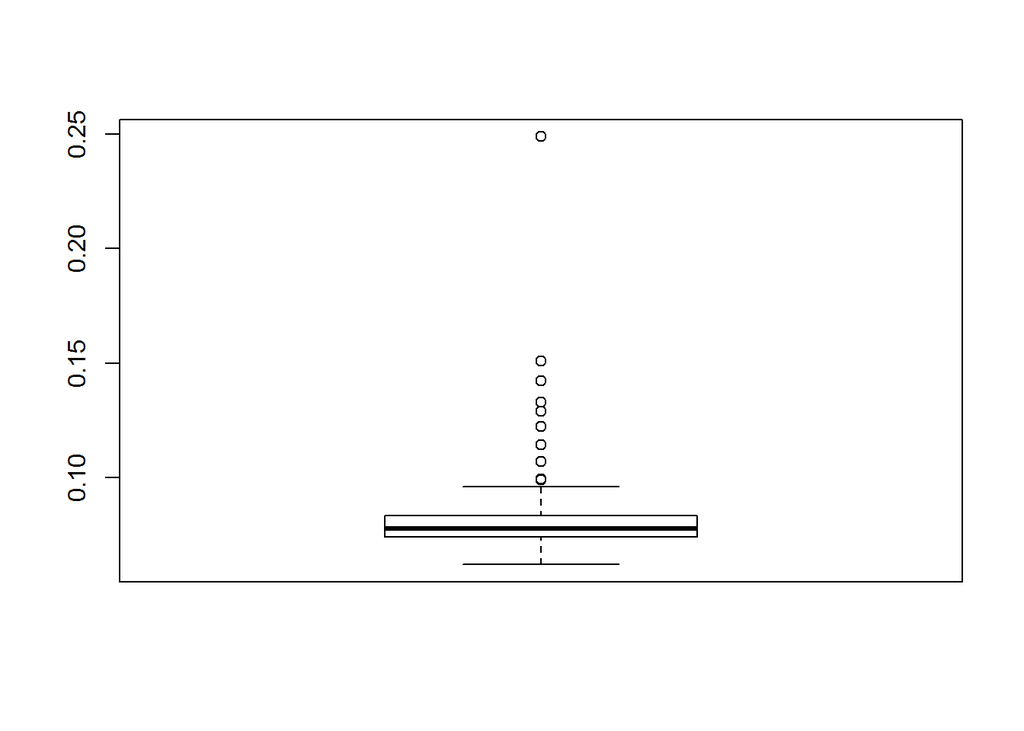

```r
demographic_data3 <- demographic_data[c("pctymle")]
boxplot(demographic_data3)
```

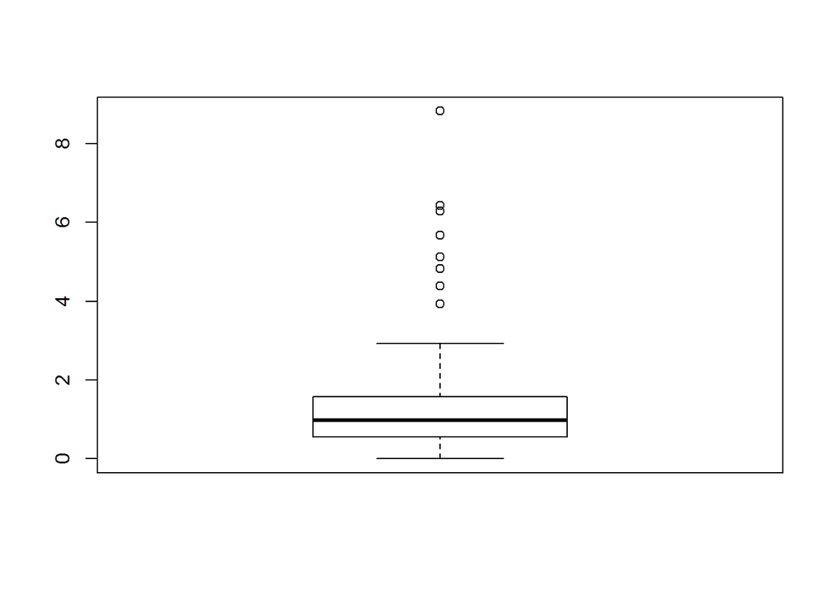

```r
demographic_data4 <- demographic_data[c("density")]
boxplot(demographic_data4)
```

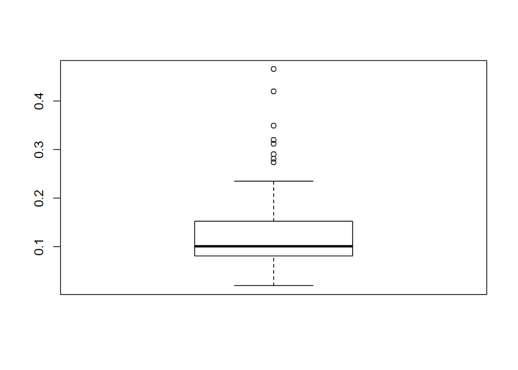

```r
demographic_data5 <- demographic_data[c("mix")]
boxplot(demographic_data5)
```

Once again we see a lot of right skewed distributions in the historgams and in the box plots.

After exploring all of the variables we decided to tranform the other variables that are potentially under a politican’s control - the deterrent variables. This gives us our final data set andso we can start running regressions.

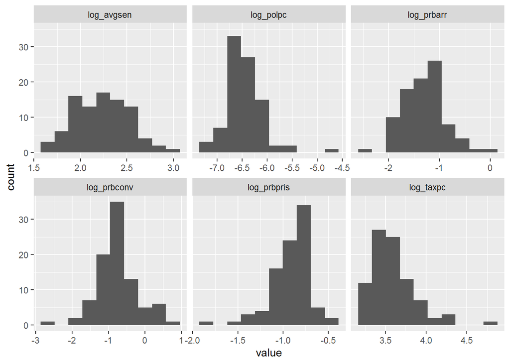

```r
data_crmrte$prbconv <- as.numeric(as.character(data_crmrte$prbconv))
data_crmrte$log_prbarr <- log(data_crmrte$prbarr)
data_crmrte$log_prbconv <- log(data_crmrte$prbconv)
data_crmrte$log_prbpris <- log(data_crmrte$prbpris)
data_crmrte$log_avgsen <- log(data_crmrte$avgsen)
data_crmrte$log_polpc <- log(data_crmrte$polpc)
data_crmrte$log_taxpc <- log(data_crmrte$taxpc)


#plot histograms of just the demographic variables
ggplot(gather(data_crmrte[,c('log_prbarr', 'log_prbconv', 'log_prbpris', 'log_avgsen', 'log_polpc', 'log_taxpc') ]), aes(value)) +
  geom_histogram(bins = 10) +
  facet_wrap(~key, scales = 'free_x')
```

Though the distribution of the variables still exhibits skew, the skew does seem to be reduced.

**Log Tranformed Dependent Variable Comparison**

In order to settle on the final data set we compare an all-in log-log model with an all-in log-linear to see which dependent variables are more suitable.

```r
###### Initial Models #####
all_in_model <- lm(crmrte ~ prbarr + prbconv + prbpris
                   + avgsen + polpc + density
                   + taxpc + west + central + urban + pctmin80 + wcon
                   + wtuc + wtrd + wfir + wser + wmfg
                   + wfed + wsta + wloc
                   + mix + pctymle,
                   data = data_crmrte)
se.all_in_model = sqrt(diag(vcovHC(all_in_model)))
coeftest(all_in_model, vcov = vcovHC)
```

```
##
## t test of coefficients:
##
##                Estimate  Std. Error t value  Pr(>|t|)
## (Intercept)  1.3853e-02  3.0755e-02  0.4504 0.6538622
## prbarr      -5.1466e-02  1.5689e-02 -3.2805 0.0016467 **
## prbconv     -1.8633e-02  6.5853e-03 -2.8295 0.0061464 **
## prbpris      3.1727e-03  1.3586e-02  0.2335 0.8160642
## avgsen      -3.9858e-04  5.5361e-04 -0.7200 0.4740570
## polpc        6.9679e+00  2.9536e+00  2.3591 0.0212406 *
## density      5.3314e-03  1.4895e-03  3.5793 0.0006464 ***
## taxpc        1.6240e-04  2.8408e-04  0.5717 0.5694537
## west        -2.5652e-03  4.4698e-03 -0.5739 0.5679579
## central     -4.2416e-03  3.7423e-03 -1.1334 0.2610725
## urban       -9.6498e-05  8.2752e-03 -0.0117 0.9907307
## pctmin80     3.2542e-04  1.3849e-04  2.3497 0.0217429 *
## wcon         2.3025e-05  3.2876e-05  0.7004 0.4861334
## wtuc         6.1914e-06  1.9862e-05  0.3117 0.7562178
## wtrd         2.8767e-05  8.7294e-05  0.3295 0.7427756
## wfir        -3.5455e-05  3.5699e-05 -0.9932 0.3242068
## wser        -1.7158e-06  9.9447e-05 -0.0173 0.9862856
## wmfg        -8.9675e-06  1.7469e-05 -0.5133 0.6094087
## wfed         2.9075e-05  3.7780e-05  0.7696 0.4442480
## wsta        -2.2302e-05  3.6828e-05 -0.6056 0.5468431
## wloc         1.4456e-05  8.5367e-05  0.1693 0.8660410
## mix         -1.8693e-02  2.2922e-02 -0.8155 0.4176761
## pctymle      1.0125e-01  4.7826e-02  2.1170 0.0379748 *
## ---
## Signif. codes:  0 '***' 0.001 '**' 0.01 '*' 0.05 '.' 0.1 ' ' 1
```

```r
AIC(all_in_model, k=2)
```

```
## [1] -585.5858
```

```r
all_in_model_log_level <- lm(log_crmrte ~ prbarr + prbconv + prbpris
                             + avgsen + polpc + density
                             + taxpc + west + central + urban
                             + pctmin80 + wcon
                             + wtuc + wtrd + wfir + wser + wmfg
                             + wfed + wsta + wloc
                             + mix + pctymle,
                             data = data_crmrte)
se.all_in_model_log_level = sqrt(diag(vcovHC(all_in_model_log_level)))
coeftest(all_in_model_log_level, vcov = vcovHC)
```

```
##
## t test of coefficients:
##
##                Estimate  Std. Error t value  Pr(>|t|)
## (Intercept) -4.0261e+00  8.4822e-01 -4.7466 1.128e-05 ***
## prbarr      -1.8891e+00  3.7955e-01 -4.9773 4.770e-06 ***
## prbconv     -6.5603e-01  1.7443e-01 -3.7611 0.0003579 ***
## prbpris     -9.3077e-02  3.9921e-01 -0.2332 0.8163542
## avgsen      -7.8769e-03  1.6125e-02 -0.4885 0.6267962
## polpc        1.5484e+02  8.6523e+01  1.7895 0.0780510 .
## density      1.1653e-01  5.4037e-02  2.1566 0.0346326 *
## taxpc        3.3224e-03  7.2890e-03  0.4558 0.6500012
## west        -1.1492e-01  1.2509e-01 -0.9187 0.3615403
## central     -1.0078e-01  9.2053e-02 -1.0948 0.2775232
## urban       -1.6923e-01  2.2872e-01 -0.7399 0.4619535
## pctmin80     9.9770e-03  3.0480e-03  3.2733 0.0016833 **
## wcon         4.6001e-04  8.3564e-04  0.5505 0.5838140
## wtuc         1.0174e-04  6.0187e-04  0.1690 0.8662750
## wtrd         2.5964e-04  1.7638e-03  0.1472 0.8834136
## wfir        -1.1015e-03  1.1960e-03 -0.9210 0.3603557
## wser        -1.3142e-04  1.5060e-03 -0.0873 0.9307193
## wmfg        -2.0528e-04  5.1630e-04 -0.3976 0.6921878
## wfed         2.3405e-03  1.0820e-03  2.1632 0.0340968 *
## wsta        -1.1357e-03  8.9769e-04 -1.2651 0.2102213
## wloc         5.8983e-04  2.4003e-03  0.2457 0.8066400
## mix         -2.3924e-01  6.2632e-01 -0.3820 0.7036869
## pctymle      2.7706e+00  1.4330e+00  1.9334 0.0574191 .
## ---
## Signif. codes:  0 '***' 0.001 '**' 0.01 '*' 0.05 '.' 0.1 ' ' 1
```

```r
AIC(all_in_model_log_level, k=2)
```

```
## [1] 21.354
```

```r
all_in_model_log_log <- lm(log_crmrte ~ log_prbarr + log_prbconv
                             + log_prbpris + log_avgsen + log_polpc
                             + density+ log_taxpc + west + central
                             + urban + pctmin80 + wcon
                             + wtuc + wtrd + wfir
                             + wser + wmfg + wfed + wsta + wloc
                             + mix + pctymle,
                             data = data_crmrte)
se.all_in_model_log_log = sqrt(diag(vcovHC(all_in_model_log_log)))
coeftest(all_in_model_log_log, vcov = vcovHC)
```

```
##
## t test of coefficients:
##
##                Estimate  Std. Error t value Pr(>|t|)
## (Intercept) -3.36882669  2.97497990 -1.1324 0.261508
## log_prbarr  -0.52143620  0.16459898 -3.1679 0.002313 **
## log_prbconv -0.33101341  0.15365522 -2.1543 0.034820 *
## log_prbpris -0.06569465  0.19741379 -0.3328 0.740342
## log_avgsen  -0.19652151  0.18205821 -1.0794 0.284261
## log_polpc    0.29132794  0.27176129  1.0720 0.287567
## density      0.12320127  0.06040422  2.0396 0.045335 *
## log_taxpc    0.06158051  0.30979897  0.1988 0.843040
## west        -0.18453792  0.16353910 -1.1284 0.263174
## central     -0.10789292  0.09991865 -1.0798 0.284100
## urban       -0.14767055  0.26670745 -0.5537 0.581641
## pctmin80     0.00956927  0.00358175  2.6717 0.009466 **
## wcon         0.00078953  0.00090745  0.8701 0.387376
## wtuc         0.00010106  0.00075559  0.1337 0.894001
## wtrd         0.00029022  0.00177967  0.1631 0.870952
## wfir        -0.00108230  0.00125937 -0.8594 0.393186
## wser        -0.00042887  0.00096365 -0.4451 0.657718
## wmfg        -0.00014147  0.00061356 -0.2306 0.818343
## wfed         0.00224918  0.00136611  1.6464 0.104363
## wsta        -0.00102039  0.00106131 -0.9614 0.339787
## wloc         0.00017815  0.00261968  0.0680 0.945986
## mix         -0.44834658  0.77846459 -0.5759 0.566587
## pctymle      2.00755501  2.60186976  0.7716 0.443075
## ---
## Signif. codes:  0 '***' 0.001 '**' 0.01 '*' 0.05 '.' 0.1 ' ' 1
```

```r
AIC(all_in_model_log_log, k=2)
```

```
## [1] 44.17803
```

```r
#Not comparing r-squared, just looking at significant variables
stargazer(all_in_model, all_in_model_log_level,
          all_in_model_log_log,
          type = "text", omit.stat = "f",
          se = list(se.all_in_model, se.all_in_model_log_level,
                    se.all_in_model_log_log),
          star.cutoffs = c(0.05, 0.01, 0.001))
```

```
##
## =============================================================
##                                     Dependent variable:
##                               -------------------------------
##                                 crmrte        log_crmrte
##                                  (1)        (2)        (3)
## -------------------------------------------------------------
## prbarr                         -0.051**  -1.889***
##                                (0.016)    (0.380)
##
## prbconv                        -0.019**  -0.656***
##                                (0.007)    (0.174)
##
## prbpris                         0.003      -0.093
##                                (0.014)    (0.399)
##
## avgsen                         -0.0004     -0.008
##                                (0.001)    (0.016)
##
## polpc                           6.968*    154.835
##                                (2.954)    (86.523)
##
## log_prbarr                                          -0.521**
##                                                      (0.165)
##
## log_prbconv                                          -0.331*
##                                                      (0.154)
##
## log_prbpris                                          -0.066
##                                                      (0.197)
##
## log_avgsen                                           -0.197
##                                                      (0.182)
##
## log_polpc                                             0.291
##                                                      (0.272)
##
## density                        0.005***    0.117*    0.123*
##                                (0.001)    (0.054)    (0.060)
##
```

[output cut: 46 more lines]

```
##                                (0.023)    (0.626)    (0.778)
##
## pctymle                         0.101*     2.771      2.008
##                                (0.048)    (1.433)    (2.602)
##
## Constant                        0.014    -4.026***   -3.369
##                                (0.031)    (0.848)    (2.975)
##
## -------------------------------------------------------------
## Observations                      90         90        90
## R2                              0.855      0.854      0.812
## Adjusted R2                     0.807      0.806      0.750
## Residual Std. Error (df = 67)   0.008      0.242      0.275
## =============================================================
## Note:                           *p<0.05; **p<0.01; ***p<0.001
```

```r
# #r-squared comparison of final two models
# yhat_level_level <- predict(all_in_model)
#
# #get the coefficients
# for (b in coef(all_in_model_log_level))
# {
#   beta_log_level <- c(beta_log_level, b)
# }
# #calculate the predictions
# for (b in coef(all_in_model_log_level))
# {
#   beta_log_level <- c(beta_log_level, b)
# }
#
# data_crmrte$log_level_yhat <- exp(--3.36882669
#                                   -0.5214362*data_crmrte$log_prbarr
#                                   -0.33101341*data_crmrte$log_prbconv
#                                   -0.06569465*data_crmrte$log_prbpris
#                                   -0.19652151*data_crmrte$log_avgsen
#                                   +0.29132794*data_crmrte$log_polpc
#                                   +0.12320127*data_crmrte$density
#                                   +0.06158051*data_crmrte$log_taxpc
#                                   -0.18453792*data_crmrte$west
#                                   -0.10789292*data_crmrte$central
#                                   -0.14767055*data_crmrte$urban
#                                   +0.00956927*data_crmrte$pctmin80
#                                   +0.00078953*data_crmrte$wcon
#                                   +0.00010106*data_crmrte$wtuc
#                                   +0.00029022*data_crmrte$wtrd
#                                   -0.0010823*data_crmrte$wfir
#                                   -0.00042887*data_crmrte$wser
#                                   -0.00014147*data_crmrte$wmfg
#                                   +0.00224918*data_crmrte$wfed
#                                   -0.00102039*data_crmrte$wsta
#                                   +0.00017815*data_crmrte$wloc
#                                   -0.44834658*data_crmrte$mix
#                                   +2.00755501*data_crmrte$pctymle
#                                   )
# r_squared_level_level <- cor(data_crmrte$crmrte, yhat_level_level)
# r_squared_log_level <- cor(data_crmrte$crmrte, data_crmrte$log_level_yhat)
# (r_squared_level_level)
# (r_squared_log_level)
```

**Model 1: Simple Model**

In order to create a simple model we decided to build using a bottom up approach. We looked at a correlation matrix

```r
#Anyone know how to print this better?
cor(data_crmrte$log_crmrte,data_crmrte)
```

```
##          county year    crmrte     prbarr    prbconv    prbpris      avgsen
## [1,] 0.02376789   NA 0.9415465 -0.4727669 -0.4468136 0.02147024 -0.04936931
##          polpc   density     taxpc       west   central     urban  pctmin80
## [1,] 0.0104058 0.6330234 0.3583234 -0.4143996 0.1847192 0.4914645 0.2329182
##           wcon      wtuc      wtrd      wfir      wser      wmfg      wfed
## [1,] 0.3937149 0.2014649 0.3937924 0.2932426 -0.113128 0.3075373 0.5233058
##           wsta      wloc        mix   pctymle log_crmrte median_wage log_prbarr
## [1,] 0.1697021 0.2885668 -0.1247344 0.2781547          1    0.454422 -0.4357539
##      log_prbconv log_prbpris log_avgsen log_polpc log_taxpc
## [1,]  -0.3724961  0.06960729 0.02341717 0.2845396 0.3398432
```

/ In the above correlation matrix, focusing on the correlations between the log_crmrte and all other variables, denisty has the highest correlation. This variable makes intuitive sense. As a single variable it might encompass a lot of other factors. Lower income people with more incentive to commit crimes tend to live in more highly populated areas. Below is the simple regression.

```r
simple_regression_model <- lm(log_crmrte ~ density, data = data_crmrte)
se.simple_regression_model = sqrt(diag(vcovHC(simple_regression_model)))
coeftest(simple_regression_model, vcov = vcovHC)
```

```
##
## t test of coefficients:
##
##              Estimate Std. Error  t value Pr(>|t|)
## (Intercept) -3.869488   0.068563 -56.4366  < 2e-16 ***
## density      0.228298   0.030439   7.5003  4.8e-11 ***
## ---
## Signif. codes:  0 '***' 0.001 '**' 0.01 '*' 0.05 '.' 0.1 ' ' 1
```

```r
AIC(simple_regression_model, k=2)
```

```
## [1] 106.2991
```

```r
stargazer(simple_regression_model,
          type = "text", omit.stat = "f",
          se = list(se.simple_regression_model),
          star.cutoffs = c(0.05, 0.01, 0.001))
```

```
##
## =================================================
##                          Dependent variable:
##                     -----------------------------
##                              log_crmrte
## -------------------------------------------------
## density                       0.228***
##                                (0.030)
##
## Constant                      -3.869***
##                                (0.069)
##
## -------------------------------------------------
## Observations                     90
## R2                              0.401
## Adjusted R2                     0.394
## Residual Std. Error        0.427 (df = 88)
## =================================================
## Note:               *p<0.05; **p<0.01; ***p<0.001
```

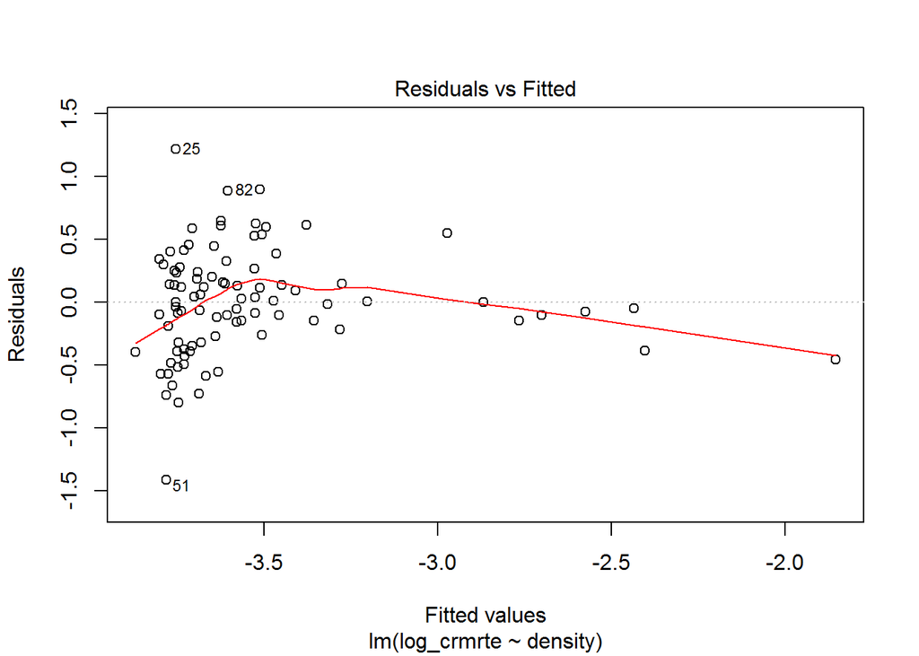

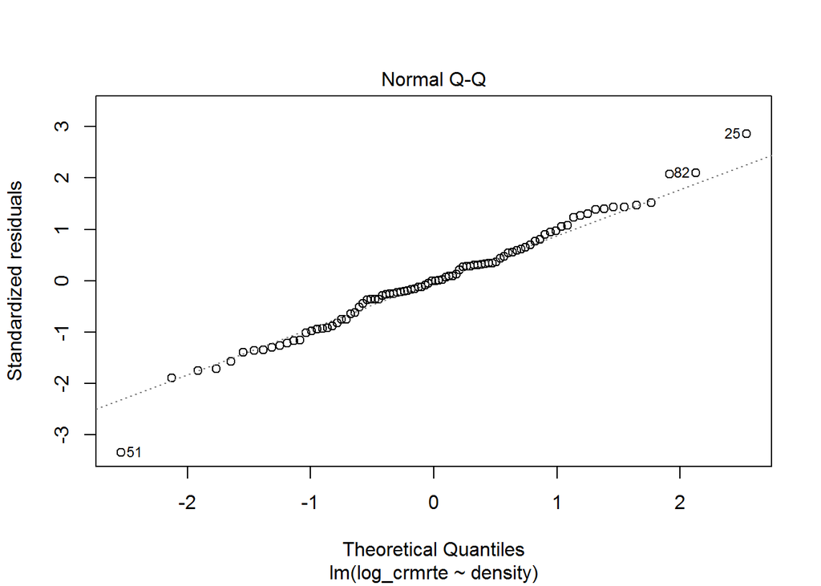

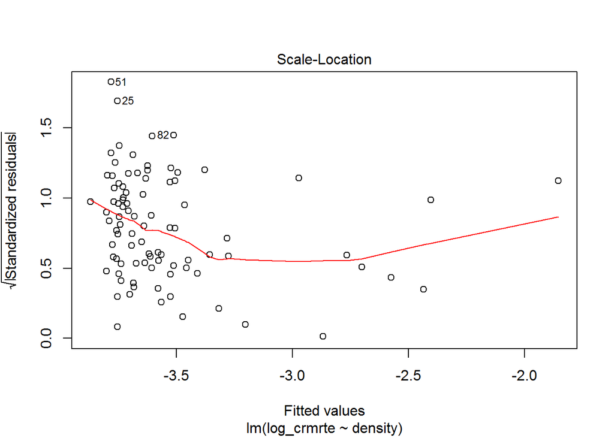

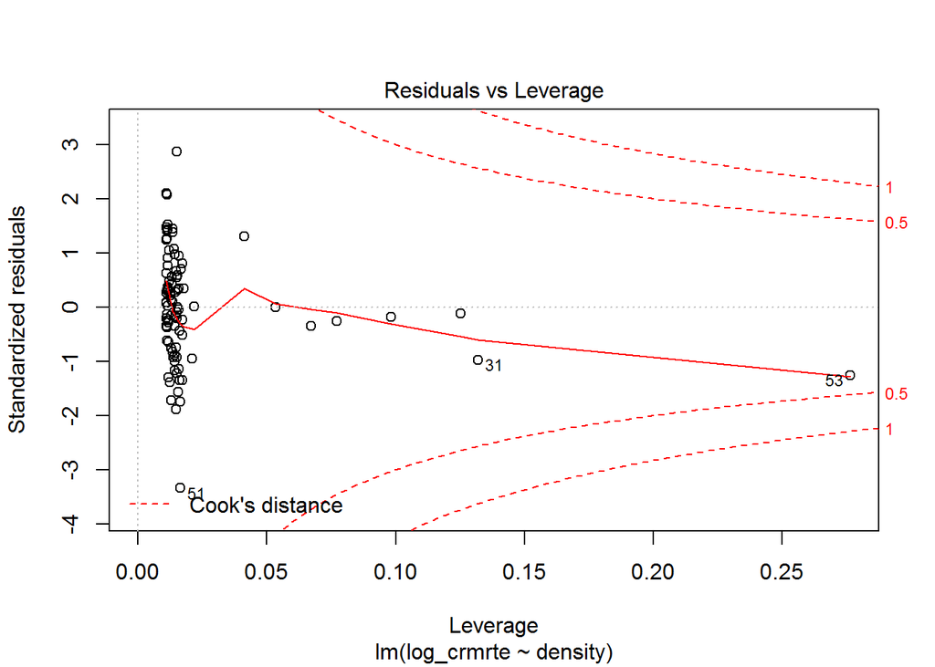

```r
plot(simple_regression_model)
```

**Model 3: Kitchen Sink Model**  
Still, we can do better in predicting the log crime rate than simply using one variable. We know examine a “kitchen sink” model. This model includes all of the variables in the data set except county (which has too many values to be a useful indicator variable) and year, which is a constant (1987). Below are the results.

```r
all_in_model_log_level <- lm(log_crmrte ~ prbarr + prbconv + prbpris
                             + avgsen + polpc + density
                             + taxpc + west + central + urban
                             + pctmin80 + wcon
                             + wtuc + wtrd + wfir + wser + wmfg
                             + wfed + wsta + wloc
                             + mix + pctymle,
                             data = data_crmrte)
se.all_in_model_log_level = sqrt(diag(vcovHC(all_in_model_log_level)))
coeftest(all_in_model_log_level, vcov = vcovHC)
```

```
##
## t test of coefficients:
##
##                Estimate  Std. Error t value  Pr(>|t|)
## (Intercept) -4.0261e+00  8.4822e-01 -4.7466 1.128e-05 ***
## prbarr      -1.8891e+00  3.7955e-01 -4.9773 4.770e-06 ***
## prbconv     -6.5603e-01  1.7443e-01 -3.7611 0.0003579 ***
## prbpris     -9.3077e-02  3.9921e-01 -0.2332 0.8163542
## avgsen      -7.8769e-03  1.6125e-02 -0.4885 0.6267962
## polpc        1.5484e+02  8.6523e+01  1.7895 0.0780510 .
## density      1.1653e-01  5.4037e-02  2.1566 0.0346326 *
## taxpc        3.3224e-03  7.2890e-03  0.4558 0.6500012
## west        -1.1492e-01  1.2509e-01 -0.9187 0.3615403
## central     -1.0078e-01  9.2053e-02 -1.0948 0.2775232
## urban       -1.6923e-01  2.2872e-01 -0.7399 0.4619535
## pctmin80     9.9770e-03  3.0480e-03  3.2733 0.0016833 **
## wcon         4.6001e-04  8.3564e-04  0.5505 0.5838140
## wtuc         1.0174e-04  6.0187e-04  0.1690 0.8662750
## wtrd         2.5964e-04  1.7638e-03  0.1472 0.8834136
## wfir        -1.1015e-03  1.1960e-03 -0.9210 0.3603557
## wser        -1.3142e-04  1.5060e-03 -0.0873 0.9307193
## wmfg        -2.0528e-04  5.1630e-04 -0.3976 0.6921878
## wfed         2.3405e-03  1.0820e-03  2.1632 0.0340968 *
## wsta        -1.1357e-03  8.9769e-04 -1.2651 0.2102213
## wloc         5.8983e-04  2.4003e-03  0.2457 0.8066400
## mix         -2.3924e-01  6.2632e-01 -0.3820 0.7036869
## pctymle      2.7706e+00  1.4330e+00  1.9334 0.0574191 .
## ---
## Signif. codes:  0 '***' 0.001 '**' 0.01 '*' 0.05 '.' 0.1 ' ' 1
```

```r
AIC(all_in_model_log_level, k=2)
```

```
## [1] 21.354
```

```r
stargazer(simple_regression_model, all_in_model_log_level,
          type = "text", omit.stat = "f",
          se = list(se.simple_regression_model, se.all_in_model_log_level),
          star.cutoffs = c(0.05, 0.01, 0.001))
```

```
##
## ===================================================
##                           Dependent variable:
##                     -------------------------------
##                               log_crmrte
##                           (1)             (2)
## ---------------------------------------------------
## prbarr                                 -1.889***
##                                         (0.380)
##
## prbconv                                -0.656***
##                                         (0.174)
##
## prbpris                                 -0.093
##                                         (0.399)
##
## avgsen                                  -0.008
##                                         (0.016)
##
## polpc                                   154.835
##                                        (86.523)
##
## density                0.228***         0.117*
##                         (0.030)         (0.054)
##
## taxpc                                    0.003
##                                         (0.007)
##
## west                                    -0.115
##                                         (0.125)
##
## central                                 -0.101
##                                         (0.092)
##
## urban                                   -0.169
##                                         (0.229)
##
## pctmin80                                0.010**
##                                         (0.003)
##
```

[output cut: 28 more lines]

```
##                                         (0.626)
##
## pctymle                                  2.771
##                                         (1.433)
##
## Constant               -3.869***       -4.026***
##                         (0.069)         (0.848)
##
## ---------------------------------------------------
## Observations              90              90
## R2                       0.401           0.854
## Adjusted R2              0.394           0.806
## Residual Std. Error 0.427 (df = 88) 0.242 (df = 67)
## ===================================================
## Note:                 *p<0.05; **p<0.01; ***p<0.001
```

Unsuprisingly, the r-squared of the “kitchen sink” model is substantially higher (85.4% vs. 40.1%). More importantly, the adjusted r-squared which accounts for the number of variables in the models, is also higher (80.6% vs 39.4%). Interestingly, density is no longer the variable with the highest statistical significance. The coefficients show the effect after all the other variables have been controlled for (partialled out). In the “kitchen sink” model prbarr and prbconv both have the lowest p-values.

With the top down approach, we started with model 3 and looked to exclude variables that weren’t as predictive. We ran hypothesis testing on all five groups, one group at a time.

```r
#deterrent
linearHypothesis(all_in_model_log_level,
                 c("prbarr = 0", "prbconv = 0", "prbpris = 0",
                   "avgsen = 0", "polpc = 0"),
                 vcov = vcovHC)
```

```
## Linear hypothesis test
##
## Hypothesis:
## prbarr = 0
## prbconv = 0
## prbpris = 0
## avgsen = 0
## polpc = 0
##
## Model 1: restricted model
## Model 2: log_crmrte ~ prbarr + prbconv + prbpris + avgsen + polpc + density +
##     taxpc + west + central + urban + pctmin80 + wcon + wtuc +
##     wtrd + wfir + wser + wmfg + wfed + wsta + wloc + mix + pctymle
##
## Note: Coefficient covariance matrix supplied.
##
##   Res.Df Df      F    Pr(>F)
## 1     72
## 2     67  5 6.0582 0.0001101 ***
## ---
## Signif. codes:  0 '***' 0.001 '**' 0.01 '*' 0.05 '.' 0.1 ' ' 1
```

```r
#wage
linearHypothesis(all_in_model_log_level,
                 c("wcon = 0", "wtuc = 0", "wtrd = 0",
                   "wfir = 0", "wser = 0", "wmfg = 0",
                   "wfed = 0", "wsta = 0", "wloc = 0"),
                 vcov = vcovHC)
```

```
## Linear hypothesis test
##
## Hypothesis:
## wcon = 0
## wtuc = 0
## wtrd = 0
## wfir = 0
## wser = 0
## wmfg = 0
## wfed = 0
## wsta = 0
## wloc = 0
##
## Model 1: restricted model
## Model 2: log_crmrte ~ prbarr + prbconv + prbpris + avgsen + polpc + density +
##     taxpc + west + central + urban + pctmin80 + wcon + wtuc +
##     wtrd + wfir + wser + wmfg + wfed + wsta + wloc + mix + pctymle
##
## Note: Coefficient covariance matrix supplied.
##
##   Res.Df Df     F Pr(>F)
## 1     76
## 2     67  9 1.372 0.2185
```

```r
#region
linearHypothesis(all_in_model_log_level,
                 c("west = 0", "central = 0"),
                 vcov = vcovHC)
```

```
## Linear hypothesis test
##
## Hypothesis:
## west = 0
## central = 0
##
## Model 1: restricted model
## Model 2: log_crmrte ~ prbarr + prbconv + prbpris + avgsen + polpc + density +
##     taxpc + west + central + urban + pctmin80 + wcon + wtuc +
##     wtrd + wfir + wser + wmfg + wfed + wsta + wloc + mix + pctymle
##
## Note: Coefficient covariance matrix supplied.
##
##   Res.Df Df     F Pr(>F)
## 1     69
## 2     67  2 0.623 0.5394
```

```r
#urban
linearHypothesis(all_in_model_log_level,
                 c("urban = 0"),
                 vcov = vcovHC)
```

```
## Linear hypothesis test
##
## Hypothesis:
## urban = 0
##
## Model 1: restricted model
## Model 2: log_crmrte ~ prbarr + prbconv + prbpris + avgsen + polpc + density +
##     taxpc + west + central + urban + pctmin80 + wcon + wtuc +
##     wtrd + wfir + wser + wmfg + wfed + wsta + wloc + mix + pctymle
##
## Note: Coefficient covariance matrix supplied.
##
##   Res.Df Df      F Pr(>F)
## 1     68
## 2     67  1 0.5474  0.462
```

```r
#demographic
linearHypothesis(all_in_model_log_level,
                 c("density = 0", "taxpc = 0", "pctmin80 = 0",
                   "mix = 0", "pctymle = 0"),
                 vcov = vcovHC)
```

```
## Linear hypothesis test
##
## Hypothesis:
## density = 0
## taxpc = 0
## pctmin80 = 0
## mix = 0
## pctymle = 0
##
## Model 1: restricted model
## Model 2: log_crmrte ~ prbarr + prbconv + prbpris + avgsen + polpc + density +
##     taxpc + west + central + urban + pctmin80 + wcon + wtuc +
##     wtrd + wfir + wser + wmfg + wfed + wsta + wloc + mix + pctymle
##
## Note: Coefficient covariance matrix supplied.
##
##   Res.Df Df      F   Pr(>F)
## 1     72
## 2     67  5 3.9627 0.003298 **
## ---
## Signif. codes:  0 '***' 0.001 '**' 0.01 '*' 0.05 '.' 0.1 ' ' 1
```

/ The hypothesis tests below show that of the five groups the only groups that are jointly significant are the deterrent data and the demographic data. These tests measure whether removing all the variables within a group reduces the r-squared by s attsitically signficant amount. We will re-run the models and compare.

```r
balanced_model_top_1 <- lm(log_crmrte ~ prbarr + prbconv + prbpris
                             + avgsen + polpc + density
                             + taxpc + pctmin80 + mix + pctymle,
                             data = data_crmrte)
se.balanced_model_top_1 = sqrt(diag(vcovHC(balanced_model_top_1)))
coeftest(balanced_model_top_1, vcov = vcovHC)
```

```
##
## t test of coefficients:
##
##                Estimate  Std. Error t value  Pr(>|t|)
## (Intercept)  -3.3522918   0.3558217 -9.4213 1.467e-14 ***
## prbarr       -1.9627484   0.4014808 -4.8888 5.228e-06 ***
## prbconv      -0.7672158   0.1366862 -5.6130 2.846e-07 ***
## prbpris      -0.0764993   0.4732818 -0.1616  0.872005
## avgsen       -0.0044749   0.0140406 -0.3187  0.750789
## polpc       176.1347220  82.5884550  2.1327  0.036056 *
## density       0.1135225   0.0351279  3.2317  0.001796 **
## taxpc         0.0020988   0.0055753  0.3764  0.707593
## pctmin80      0.0125062   0.0016215  7.7128 3.155e-11 ***
## mix          -0.7304967   0.5396416 -1.3537  0.179702
## pctymle       1.3832565   1.6211791  0.8532  0.396105
## ---
## Signif. codes:  0 '***' 0.001 '**' 0.01 '*' 0.05 '.' 0.1 ' ' 1
```

```r
AIC(balanced_model_top_1, k=2)
```

```
## [1] 27.4514
```

```r
stargazer(simple_regression_model, all_in_model_log_level, balanced_model_top_1,
          type = "text", omit.stat = "f",
          se = list(se.simple_regression_model, se.all_in_model_log_level, se.balanced_model_top_1),
          star.cutoffs = c(0.05, 0.01, 0.001))
```

```
##
## ===================================================================
##                                   Dependent variable:
##                     -----------------------------------------------
##                                       log_crmrte
##                           (1)             (2)             (3)
## -------------------------------------------------------------------
## prbarr                                 -1.889***       -1.963***
##                                         (0.380)         (0.401)
##
## prbconv                                -0.656***       -0.767***
##                                         (0.174)         (0.137)
##
## prbpris                                 -0.093          -0.076
##                                         (0.399)         (0.473)
##
## avgsen                                  -0.008          -0.004
##                                         (0.016)         (0.014)
##
## polpc                                   154.835        176.135*
##                                        (86.523)        (82.588)
##
## density                0.228***         0.117*          0.114**
##                         (0.030)         (0.054)         (0.035)
##
## taxpc                                    0.003           0.002
##                                         (0.007)         (0.006)
##
## west                                    -0.115
##                                         (0.125)
##
## central                                 -0.101
##                                         (0.092)
##
## urban                                   -0.169
##                                         (0.229)
##
## pctmin80                                0.010**        0.013***
##                                         (0.003)         (0.002)
##
```

[output cut: 28 more lines]

```
##                                         (0.626)         (0.540)
##
## pctymle                                  2.771           1.383
##                                         (1.433)         (1.621)
##
## Constant               -3.869***       -4.026***       -3.352***
##                         (0.069)         (0.848)         (0.356)
##
## -------------------------------------------------------------------
## Observations              90              90              90
## R2                       0.401           0.854           0.796
## Adjusted R2              0.394           0.806           0.770
## Residual Std. Error 0.427 (df = 88) 0.242 (df = 67) 0.263 (df = 79)
## ===================================================================
## Note:                                 *p<0.05; **p<0.01; ***p<0.001
```

```r
balanced_model_top_2 <- lm(log_crmrte ~ prbarr + prbconv + prbpris
                             + avgsen + polpc + density
                             + taxpc + pctmin80 + mix + pctymle
                             + median_wage,
                             data = data_crmrte)
se.balanced_model_top_2 = sqrt(diag(vcovHC(balanced_model_top_2)))
coeftest(balanced_model_top_2, vcov = vcovHC)
```

```
##
## t test of coefficients:
##
##                Estimate  Std. Error t value  Pr(>|t|)
## (Intercept)  -3.7018614   0.6241512 -5.9310 7.799e-08 ***
## prbarr       -1.9379154   0.4176289 -4.6403 1.381e-05 ***
## prbconv      -0.7650603   0.1360985 -5.6214 2.826e-07 ***
## prbpris      -0.1114352   0.4509889 -0.2471  0.805487
## avgsen       -0.0046181   0.0137443 -0.3360  0.737770
## polpc       167.9127417  85.2311288  1.9701  0.052378 .
## density       0.0977596   0.0343625  2.8450  0.005671 **
## taxpc         0.0020705   0.0056750  0.3648  0.716214
## pctmin80      0.0123893   0.0016202  7.6467 4.534e-11 ***
## mix          -0.5896970   0.5806401 -1.0156  0.312961
## pctymle       1.5670818   1.9109317  0.8201  0.414680
## median_wage   0.0011536   0.0014133  0.8162  0.416848
## ---
## Signif. codes:  0 '***' 0.001 '**' 0.01 '*' 0.05 '.' 0.1 ' ' 1
```

```r
AIC(balanced_model_top_2, k=2)
```

```
## [1] 28.07462
```

```r
stargazer(simple_regression_model, all_in_model_log_level, balanced_model_top_1, balanced_model_top_2,
          type = "text", omit.stat = "f",
          se = list(se.simple_regression_model, se.all_in_model_log_level,
                    se.balanced_model_top_1, se.balanced_model_top_2),
          star.cutoffs = c(0.05, 0.01, 0.001))
```

```
##
## ===================================================================================
##                                           Dependent variable:
##                     ---------------------------------------------------------------
##                                               log_crmrte
##                           (1)             (2)             (3)             (4)
## -----------------------------------------------------------------------------------
## prbarr                                 -1.889***       -1.963***       -1.938***
##                                         (0.380)         (0.401)         (0.418)
##
## prbconv                                -0.656***       -0.767***       -0.765***
##                                         (0.174)         (0.137)         (0.136)
##
## prbpris                                 -0.093          -0.076          -0.111
##                                         (0.399)         (0.473)         (0.451)
##
## avgsen                                  -0.008          -0.004          -0.005
##                                         (0.016)         (0.014)         (0.014)
##
## polpc                                   154.835        176.135*        167.913*
##                                        (86.523)        (82.588)        (85.231)
##
## density                0.228***         0.117*          0.114**         0.098**
##                         (0.030)         (0.054)         (0.035)         (0.034)
##
## taxpc                                    0.003           0.002           0.002
##                                         (0.007)         (0.006)         (0.006)
##
## west                                    -0.115
##                                         (0.125)
##
## central                                 -0.101
##                                         (0.092)
##
## urban                                   -0.169
##                                         (0.229)
##
## pctmin80                                0.010**        0.013***        0.012***
##                                         (0.003)         (0.002)         (0.002)
##
```

[output cut: 31 more lines]

```
##                                         (1.433)         (1.621)         (1.911)
##
## median_wage                                                              0.001
##                                                                         (0.001)
##
## Constant               -3.869***       -4.026***       -3.352***       -3.702***
##                         (0.069)         (0.848)         (0.356)         (0.624)
##
## -----------------------------------------------------------------------------------
## Observations              90              90              90              90
## R2                       0.401           0.854           0.796           0.799
## Adjusted R2              0.394           0.806           0.770           0.770
## Residual Std. Error 0.427 (df = 88) 0.242 (df = 67) 0.263 (df = 79) 0.263 (df = 78)
## ===================================================================================
## Note:                                                 *p<0.05; **p<0.01; ***p<0.001
```